# 2. Linear models of protection and complexity

Tal Gavriel

2025-03-18

```r
library(DarkDiv)
library(tidyverse)
library(vegan)
library(plotrix)
library(sjPlot)
library(sjmisc)
library(gridExtra)
library(lme4)
library(lmerTest)
library(MuMIn)
library(glmmTMB)
library(DHARMa)
library(ggeffects)
library(patchwork)

select <- dplyr::select
```

# In this script:

1. Models of the realtionship between `Protection` and diversity componenets - `dark diversity`, `observed richness`, `species pool` and `completness`
2. Models of the realtionship between `Complexity` and diversity componenets - `dark diversity`, `observed richness`, `species pool` and `completness`

# Input files:

loaded from the `clean output data` folder

- `Clean_medata_dd.Rdata` - dark diversity calculation for MeData, with Lisandro data
- `Clean_complexity_dd.Rdata` - dark diversity calculation for the Israel complexity data
- `pairs.Rdata` - pairs of protected and control sites

# Outputs files:

**Models tables**

- `protection_model_results.xls` - tables for protection models
- `curvature_model_results.xls` - tables for Curvature complexity models
- `vr_model_results.xls` - tables for vertical relief complexity modeld
- `completenes_model_results` - All completeness models
- `ms_curve` - model selection between additive and interaction models for curvature (Appendix)
- `ms_vr`- model selection between additive and interaction models for vertical relief (Appendix)

**Plots**

- `predictions_plot.pdf` - plot of protection + curvature models (Fig 3)
- `vr_predictions_plot.pdf`- plot of vertical relief models (Appendix)
- `completeness_prediction_plot`- plots of completeness (Appendix)

# Protection models

load `dd_data` data

```r
load("Clean_MeData_dd.Rdata")

load("pairs.Rdata")
```

## Final data preparation:

1. Keep in the models only paired sites of no protection vs fully or partly protected
2. Remove transect with 1 species in the observed richness
3. Treat enforcement as factor

```r
pairs$Cluster <- coalesce(pairs$Cluster, pairs$pair)

cluster<-pairs %>% select(-pair) %>% distinct() %>% rename(pair = Cluster)
```

```r
protction_model_data<-left_join(dd_data,cluster)
```

```r
protction_model_data<-protction_model_data %>% drop_na(pair)

# which pairs I have in the data:

unique(protction_model_data$pair)
```

```
##  [1] "Brijoni"                       "Porto Cesareo - Torre_guaceto"
##  [3] "Banyuls"                       "Portofino"
##  [5] "Tavolara - Asinara"            "Medes-cap_de_creus"
##  [7] "gdor"                          "shikmona"
##  [9] "achziv"                        "Ustica-Marettimo"
## [11] "Formentera"                    "Cabrera"
## [13] "Cavalleria"
```

```r
# how many pairs:

length(unique(protction_model_data$pair))
```

```
## [1] 13
```

```r
# which sites I have in the data

unique(protction_model_data$Site)
```

```
##  [1] brijuni        otranto        torre_guaceto  porto_cesareo  Banyuls
##  [6] portofino      genova         carloforte     medes          montgri
## [11] cap_de_creus   asinara        gdor           shikmona       achziv
## [16] marettimo      san_vito       ustica         tavolara       formentera
## [21] eivissa        cabrera        dragonera      illa_de_l'aire cavalleria
## 55 Levels: achziv adrasan Akamas Akrotiri alonissos asinara ayvalik ... ustica
```

```r
# How many sites:

length(unique(protction_model_data$Site))
```

```
## [1] 25
```

```r
#  richness <1

protction_model_data<-protction_model_data %>% filter(observed_richness >1)

# drop sites level

protction_model_data$Site<-droplevels(protction_model_data$Site)

# How many transects in each pair:

summary.factor(protction_model_data$pair)
```

```
##                        achziv                       Banyuls
##                           149                            42
##                       Brijoni                       Cabrera
##                            72                            36
##                    Cavalleria                    Formentera
##                            36                            36
##                          gdor            Medes-cap_de_creus
##                           135                            54
## Porto Cesareo - Torre_guaceto                     Portofino
##                            54                            30
##                      shikmona            Tavolara - Asinara
##                           126                           243
##              Ustica-Marettimo
##                           120
```

```r
# convert to factor

protction_model_data$enforcement<-as.factor(protction_model_data$enforcement)

# how many from each enforcement level:

summary.factor(protction_model_data$enforcement)
```

```
##   0   2   3
## 379 425 329
```

## Dark diversity model

new option

```r
# run model

Dark <- glmmTMB(log(dark+1) ~ enforcement + (1|pair),
                  data = protction_model_data,
                  family = gaussian())

# model summary

summary(Dark)
```

```
##  Family: gaussian  ( identity )
## Formula:          log(dark + 1) ~ enforcement + (1 | pair)
## Data: protction_model_data
##
##      AIC      BIC   logLik deviance df.resid
##   1479.6   1504.8   -734.8   1469.6     1128
##
## Random effects:
##
## Conditional model:
##  Groups   Name        Variance Std.Dev.
##  pair     (Intercept) 0.6222   0.7888
##  Residual             0.2014   0.4488
## Number of obs: 1133, groups:  pair, 13
##
## Dispersion estimate for gaussian family (sigma^2): 0.201
##
## Conditional model:
##               Estimate Std. Error z value Pr(>|z|)
## (Intercept)   1.280326   0.220121   5.816 6.01e-09 ***
## enforcement2  0.008572   0.034862   0.246   0.8058
## enforcement3 -0.090771   0.037522  -2.419   0.0156 *
## ---
## Signif. codes:  0 '***' 0.001 '**' 0.01 '*' 0.05 '.' 0.1 ' ' 1
```

```r
# residuals check

#plot(simulateResiduals(Dark))

# prediction for the different enforcement levels

pred_dark = ggpredict(Dark,terms = 'enforcement')
```

```
## Model has log-transformed response. Back-transforming predictions to
##   original response scale. Standard errors are still on the log-scale.
```

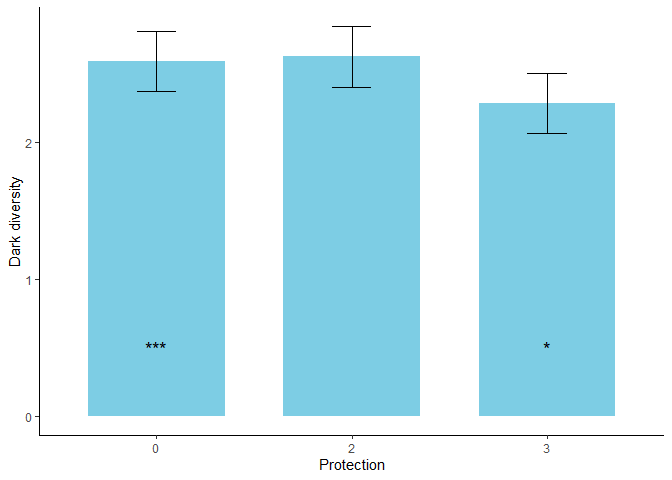

```r
# extract the p-value for the plot


p <-summary(Dark)

p0<-round(as.numeric(p[["coefficients"]][["cond"]][[10]]),3)
p2<-round(as.numeric(p[["coefficients"]][["cond"]][[11]]),3)
p3<-round(as.numeric(p[["coefficients"]][["cond"]][[12]]),3)

pval<-data.frame(enforcement = as.factor(c("0","2","3")),
                 p_val = c(p0,p2,p3))

# add significant signs

pval<- pval %>% mutate(sign = case_when(p_val > 0.1 ~ "",
                                        p_val > 0.05 & p_val <= 0.1 ~ "",
                                        p_val > 0.01 & p_val <= 0.05 ~ "*",
                                        p_val > 0.001 & p_val <= 0.01 ~ "**",
                                        p_val <= 0.001 ~ "***"))


plot_dark_pro <- ggplot(data = pred_dark, aes(x = x, y = predicted)) +
  geom_bar(stat = "identity", fill = "#7DCDE4", width = 0.7) +
  geom_errorbar(aes(ymin = predicted - std.error, ymax = predicted + std.error),
                width = 0.2, color = "black", position = position_dodge(width = 0.7)) +
  xlab("Protection") +
  scale_x_discrete(labels = levels(protction_model_data$enforcement)) +
  geom_text(data = pval,
            aes(x = enforcement,y =  0.5, label = sign),
            size = 5)+
  ylab("Dark diversity") + theme_classic()

plot_dark_pro
```

```r
rm(p,p0,p2,p3,pval,pred_dark)
```

## Observed richness model

new version

```r
# run model

Observed <- glmmTMB(log(observed_richness) ~ enforcement + (1|pair),
                  data = protction_model_data,
                  family = gaussian())
# model summary

summary(Observed)
```

```
##  Family: gaussian  ( identity )
## Formula:          log(observed_richness) ~ enforcement + (1 | pair)
## Data: protction_model_data
##
##      AIC      BIC   logLik deviance df.resid
##    779.0    804.1   -384.5    769.0     1128
##
## Random effects:
##
## Conditional model:
##  Groups   Name        Variance Std.Dev.
##  pair     (Intercept) 0.1271   0.3566
##  Residual             0.1097   0.3313
## Number of obs: 1133, groups:  pair, 13
##
## Dispersion estimate for gaussian family (sigma^2): 0.11
##
## Conditional model:
##              Estimate Std. Error z value Pr(>|z|)
## (Intercept)   2.17128    0.10051  21.603   <2e-16 ***
## enforcement2  0.01986    0.02572   0.772    0.440
## enforcement3  0.03823    0.02768   1.381    0.167
## ---
## Signif. codes:  0 '***' 0.001 '**' 0.01 '*' 0.05 '.' 0.1 ' ' 1
```

```r
# plot Residuals

#plot(simulateResiduals(Observed))

# predict the values for the differnt enforcment level

pred_observed <- ggpredict(Observed, terms = "enforcement")
```

```
## Model has log-transformed response. Back-transforming predictions to
##   original response scale. Standard errors are still on the log-scale.
```

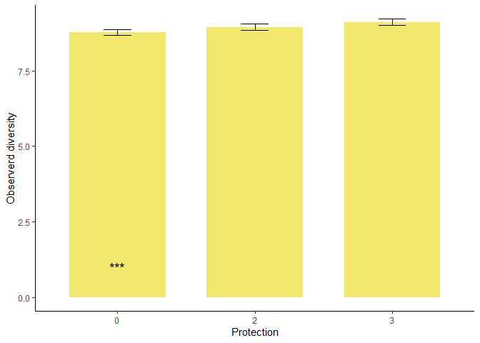

```r
# extract the p-value for the plot


p <-summary(Observed)

p0<-round(as.numeric(p[["coefficients"]][["cond"]][[10]]),3)
p2<-round(as.numeric(p[["coefficients"]][["cond"]][[11]]),3)
p3<-round(as.numeric(p[["coefficients"]][["cond"]][[12]]),3)

pval<-data.frame(enforcement = as.factor(c("0","2","3")),
                 p_val = c(p0,p2,p3))

# add significant signs

pval<- pval %>% mutate(sign = case_when(p_val > 0.1 ~ "",
                                        p_val > 0.05 & p_val <= 0.1 ~ "",
                                        p_val > 0.01 & p_val <= 0.05 ~ "*",
                                        p_val > 0.001 & p_val <= 0.01 ~ "**",
                                        p_val <= 0.001 ~ "***"))
# plot

plot_obsrved_pro <- ggplot(data = pred_observed, aes(x = x, y = predicted)) +
  geom_bar(stat = "identity", fill = "#F2E96C", width = 0.7) +
  geom_errorbar(aes(ymin = predicted - std.error, ymax = predicted + std.error), width = 0.2, color = "black", position = position_dodge(width = 0.7)) +
  xlab("Protection") +
  scale_x_discrete(labels = levels(protction_model_data$enforcement)) +
  geom_text(data = pval,
            aes(x = enforcement,y =  1, label = sign),
            size = 5)+
  ylab("Observerd diversity") + theme_classic()

plot_obsrved_pro
```

```r
rm(p,p0,p2,p3,pval,pred_observed)
```

## species pool model

```r
# run model

Total <- glmmTMB(log(total) ~ enforcement + (1|pair),
                  data = protction_model_data,family = gaussian())
# summary

summary(Total)
```

```
##  Family: gaussian  ( identity )
## Formula:          log(total) ~ enforcement + (1 | pair)
## Data: protction_model_data
##
##      AIC      BIC   logLik deviance df.resid
##   -390.6   -365.4    200.3   -400.6     1128
##
## Random effects:
##
## Conditional model:
##  Groups   Name        Variance Std.Dev.
##  pair     (Intercept) 0.03437  0.1854
##  Residual             0.03921  0.1980
## Number of obs: 1133, groups:  pair, 13
##
## Dispersion estimate for gaussian family (sigma^2): 0.0392
##
## Conditional model:
##               Estimate Std. Error z value Pr(>|z|)
## (Intercept)   2.591723   0.052522   49.35   <2e-16 ***
## enforcement2 -0.005779   0.015367   -0.38    0.707
## enforcement3  0.001243   0.016550    0.08    0.940
## ---
## Signif. codes:  0 '***' 0.001 '**' 0.01 '*' 0.05 '.' 0.1 ' ' 1
```

```r
# residuals

#plot(simulateResiduals(Total))

# predicted values for the enforcment levels

pred_total=ggpredict(Total,terms = "enforcement")
```

```
## Model has log-transformed response. Back-transforming predictions to
##   original response scale. Standard errors are still on the log-scale.
```

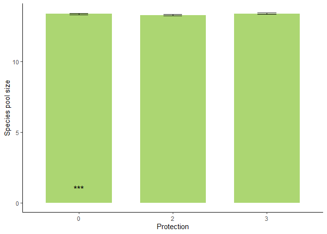

```r
# get p-values for the plot

p <-summary(Total)

p0 <- round(as.numeric(p[["coefficients"]][["cond"]][[10]]),3)
p2 <- round(as.numeric(p[["coefficients"]][["cond"]][[11]]),3)
p3 <- round(as.numeric(p[["coefficients"]][["cond"]][[12]]),3)

pval <-data.frame(enforcement = as.factor(c("0","2","3")),
                 p_val = c(p0,p2,p3))

# add significant signs

pval <- pval %>% mutate(sign = case_when(p_val > 0.1 ~ "",
                                        p_val > 0.05 & p_val <= 0.1 ~ "",
                                        p_val > 0.01 & p_val <= 0.05 ~ "*",
                                        p_val > 0.005 & p_val <= 0.01 ~ "**",
                                        p_val <= 0.005 ~ "***"))

# plot

plot_total_pro <- ggplot(data = pred_total, aes(x = x, y = predicted)) +
  geom_bar(stat = "identity", fill = "#ACD672", width = 0.7) +
  geom_errorbar(aes(ymin = predicted - std.error, ymax = predicted + std.error), width = 0.2, color = "black", position = position_dodge(width = 0.7)) +
  xlab("Protection") +
  scale_x_discrete(labels = levels(protction_model_data$enforcement)) +
  geom_text(data = pval,
            aes(x = enforcement,y =  1, label = sign),
            size = 5)+
  ylab("Species pool size") + theme_classic()

plot_total_pro
```

```r
rm(p,p0,p2,p3,pval,pred_total)
```

## save protection models tables

models summery tables:

```r
#tab_model(Total, Observed, Dark, dv.labels = c("Species pool", "Observed richness", "Dark diversity"), file = "protection_model_results_new.xls")
```

## completeness - protection model

Some transect have dark diversity = 0 and thus produce INF values, those transects was filterd out of this analyses.

```r
completeness<-protction_model_data %>%
  mutate(completeness = log(dark/observed_richness)) %>% filter(completeness != -Inf)


completeness_model <- glmmTMB(completeness ~ enforcement + (1|pair),
                  data = completeness,family = gaussian())

summary(completeness_model)
```

```
##  Family: gaussian  ( identity )
## Formula:          completeness ~ enforcement + (1 | pair)
## Data: completeness
##
##      AIC      BIC   logLik deviance df.resid
##   2115.1   2139.4  -1052.6   2105.1      946
##
## Random effects:
##
## Conditional model:
##  Groups   Name        Variance Std.Dev.
##  pair     (Intercept) 0.9137   0.9559
##  Residual             0.5048   0.7105
## Number of obs: 951, groups:  pair, 13
##
## Dispersion estimate for gaussian family (sigma^2): 0.505
##
## Conditional model:
##              Estimate Std. Error z value Pr(>|z|)
## (Intercept)  -0.96254    0.27130  -3.548 0.000388 ***
## enforcement2 -0.04126    0.06086  -0.678 0.497769
## enforcement3 -0.08401    0.06404  -1.312 0.189574
## ---
## Signif. codes:  0 '***' 0.001 '**' 0.01 '*' 0.05 '.' 0.1 ' ' 1
```

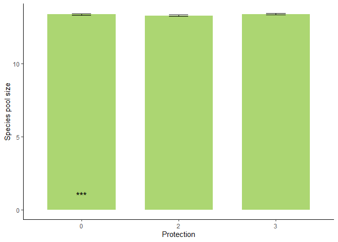

```r
#plot(simulateResiduals(completeness_model))

pred_completeness=ggpredict(completeness_model,terms = c('enforcement'))

# get p-values for the plot

p <-summary(completeness_model)

p0 <- round(as.numeric(p[["coefficients"]][["cond"]][[10]]),3)
p2 <- round(as.numeric(p[["coefficients"]][["cond"]][[11]]),3)
p3 <- round(as.numeric(p[["coefficients"]][["cond"]][[12]]),3)

pval <-data.frame(enforcement = as.factor(c("0","2","3")),
                 p_val = c(p0,p2,p3))

# add significant signs

pval <- pval %>% mutate(sign = case_when(p_val > 0.1 ~ "",
                                        p_val > 0.05 & p_val <= 0.1 ~ "",
                                        p_val > 0.01 & p_val <= 0.05 ~ "*",
                                        p_val > 0.001 & p_val <= 0.01 ~ "**",
                                        p_val <= 0.001 ~ "***"))

# plot

plot_completness_pro <- ggplot(data = pred_completeness, aes(x = x, y = predicted)) +
  geom_bar(stat = "identity", fill = "red", width = 0.7) +
  geom_errorbar(aes(ymin = predicted - std.error, ymax = predicted + std.error), width = 0.2, color = "black", position = position_dodge(width = 0.7)) +
  xlab("Protection") +
  scale_x_discrete(labels = levels(protction_model_data$enforcement)) +
  geom_text(data = pval,
            aes(x = enforcement,y =  -0.2, label = sign),
            size = 5)+
  ylab("Completeness") + theme_classic()+ geom_hline(yintercept=0)

plot_total_pro
```

```r
rm(p,p0,p2,p3,pval,pred_completeness)
```

save completeness model table

```r
#tab_model(completeness_model,file = "Completeness_protection_model_new.xls")
```

# Complexity models

load complexity dark diversity data - `Clean_complexity_dd.Rdata`

(loaded as `comp_dd`)

```r
load("Clean_complexity_dd.Rdata")
```

### final data orgenaizing

Data preparation for model

```r
# remove transect with less than 2 species in the observed

complexity_for_model<-comp_dd %>% filter(observed_richness >1)

# add column with completeness calculation

complexity_for_model<-complexity_for_model %>%
  mutate(completeness = log(observed_richness/dark))

# data for completeness models without INF values

complexity_comp <-complexity_for_model %>% filter(completeness != Inf)
```

first are all code for the models of the curvature complexity index (Figure 3)

second are all code for the models of the vertical relief complexity index (Appendix)

## Curvature index

#### Curvature dark diversity

```r
# run model

curv_dark<-glmmTMB(log(dark+1) ~  Curvature + protection + (1|site), data=complexity_for_model,family = gaussian())

# summary

summary(curv_dark)
```

```
##  Family: gaussian  ( identity )
## Formula:          log(dark + 1) ~ Curvature + protection + (1 | site)
## Data: complexity_for_model
##
##      AIC      BIC   logLik deviance df.resid
##    322.3    338.2   -156.1    312.3      174
##
## Random effects:
##
## Conditional model:
##  Groups   Name        Variance Std.Dev.
##  site     (Intercept) 0.01689  0.1300
##  Residual             0.32637  0.5713
## Number of obs: 179, groups:  site, 4
##
## Dispersion estimate for gaussian family (sigma^2): 0.326
##
## Conditional model:
##                     Estimate Std. Error z value Pr(>|z|)
## (Intercept)          0.94876    0.09136  10.385   <2e-16 ***
## Curvature           -0.02498    0.05451  -0.458    0.647
## protectionProtected -0.03569    0.08628  -0.414    0.679
## ---
## Signif. codes:  0 '***' 0.001 '**' 0.01 '*' 0.05 '.' 0.1 ' ' 1
```

```r
# residuals plots

#plot(simulateResiduals(curv_dark))

# predicted dark diversity for curvature values

dark_curv_predict =ggpredict(curv_dark,terms = c('Curvature[-2:4 by=0.5]'))
```

```
## Model has log-transformed response. Back-transforming predictions to
##   original response scale. Standard errors are still on the log-scale.
```

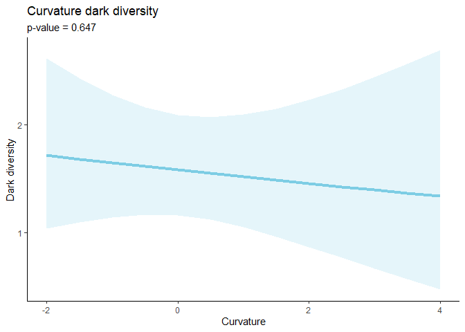

```r
# add p-value for the plot

p <-summary(curv_dark)

p<-round(as.numeric(p[["coefficients"]][["cond"]][[11]]),3)

subtitle<- paste0("p-value = ",p)

# plot

plot_dark_curv <-ggplot()+
  geom_line(data = dark_curv_predict,aes(x= x,y = predicted),size=1.5,color= "#7DCDE4")+
  geom_ribbon(data = dark_curv_predict,aes(x=x,ymin=conf.low,ymax=conf.high),alpha=0.2,fill="#7DCDE4")+
  ggtitle(label = "Curvature dark diversity",
          subtitle = subtitle)+
  xlab("Curvature") +
  ylab("Dark diversity")+theme_classic()
plot_dark_curv
```

```r
rm(p,subtitle,dark_curv_predict)
```

#### Curvature observed richness

```r
# run model

curv_observed<-glmmTMB(log(observed_richness) ~  Curvature + protection + (1|site), data=complexity_for_model,family = gaussian())

# summary

summary(curv_observed)
```

```
##  Family: gaussian  ( identity )
## Formula:          log(observed_richness) ~ Curvature + protection + (1 | site)
## Data: complexity_for_model
##
##      AIC      BIC   logLik deviance df.resid
##    198.1    214.1    -94.1    188.1      174
##
## Random effects:
##
## Conditional model:
##  Groups   Name        Variance Std.Dev.
##  site     (Intercept) 0.01813  0.1347
##  Residual             0.16100  0.4013
## Number of obs: 179, groups:  site, 4
##
## Dispersion estimate for gaussian family (sigma^2): 0.161
##
## Conditional model:
##                     Estimate Std. Error z value Pr(>|z|)
## (Intercept)          1.39709    0.08101  17.247   <2e-16 ***
## Curvature            0.07105    0.03982   1.784   0.0744 .
## protectionProtected  0.09233    0.06063   1.523   0.1278
## ---
## Signif. codes:  0 '***' 0.001 '**' 0.01 '*' 0.05 '.' 0.1 ' ' 1
```

```r
# residuals

#plot(simulateResiduals(curv_observed))

# predicted richness

obs_curv_predict=ggpredict(curv_observed,terms = c('Curvature[-2:4 by=0.5]'))
```

```
## Model has log-transformed response. Back-transforming predictions to
##   original response scale. Standard errors are still on the log-scale.
```

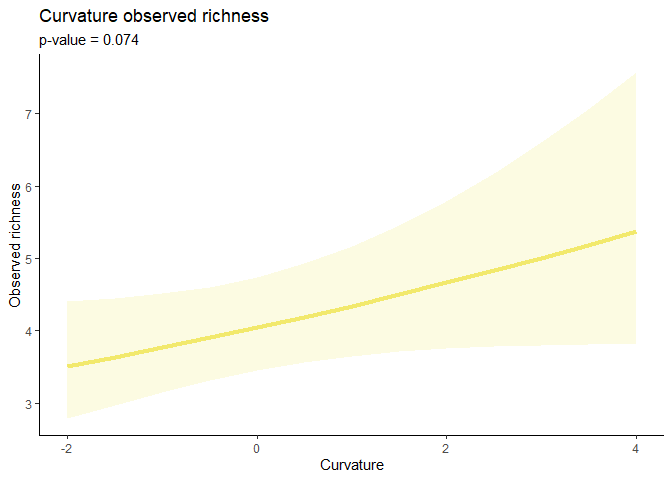

```r
# add p-value for the plot

p <-summary(curv_observed)

p<-round(as.numeric(p[["coefficients"]][["cond"]][[11]]),3)

subtitle<- paste0("p-value = ",p)

# plot

plot_observed_curv <- ggplot()+
  geom_line(data = obs_curv_predict,aes(x= x,y = predicted),size= 1.5,color= "#F2E96C")+
  geom_ribbon(data = obs_curv_predict,aes(x=x,ymin=conf.low,ymax=conf.high),alpha= 0.2,fill="#F2E96C")+
  ggtitle(label = "Curvature observed richness",
          subtitle = subtitle)+
  xlab("Curvature") +
  ylab("Observed richness")+theme_classic()

plot_observed_curv
```

```r
rm(p,subtitle,obs_curv_predict)
```

#### Curvature species pool

```r
# run model

curv_total <- glmmTMB(log(total) ~  Curvature + protection + (1|site), data=complexity_for_model,family = gaussian())

# summary

summary(curv_total)
```

```
##  Family: gaussian  ( identity )
## Formula:          log(total) ~ Curvature + protection + (1 | site)
## Data: complexity_for_model
##
##      AIC      BIC   logLik deviance df.resid
##     26.0     41.9     -8.0     16.0      174
##
## Random effects:
##
## Conditional model:
##  Groups   Name        Variance Std.Dev.
##  site     (Intercept) 0.006112 0.07818
##  Residual             0.061679 0.24835
## Number of obs: 179, groups:  site, 4
##
## Dispersion estimate for gaussian family (sigma^2): 0.0617
##
## Conditional model:
##                     Estimate Std. Error z value Pr(>|z|)
## (Intercept)          1.82467    0.04799   38.02   <2e-16 ***
## Curvature            0.04383    0.02452    1.79   0.0738 .
## protectionProtected  0.05872    0.03752    1.56   0.1176
## ---
## Signif. codes:  0 '***' 0.001 '**' 0.01 '*' 0.05 '.' 0.1 ' ' 1
```

```r
# plot residuals

#plot(simulateResiduals(curv_total))


# predicted species pool values

sppool_curv_pred =ggpredict(curv_total,terms = c('Curvature[-2:4 by=0.5]'))
```

```
## Model has log-transformed response. Back-transforming predictions to
##   original response scale. Standard errors are still on the log-scale.
```

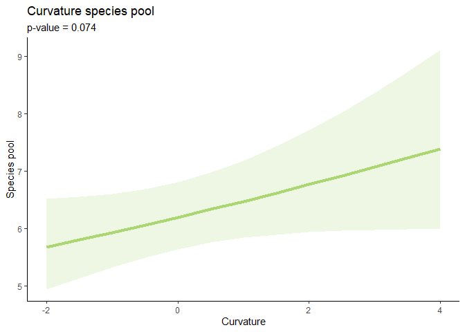

```r
# add p-value for the plot

p <-summary(curv_total)

p<-round(as.numeric(p[["coefficients"]][["cond"]][[11]]),3)

subtitle<- paste0("p-value = ",p)

plot_total_curv<-ggplot()+
  geom_line(data = sppool_curv_pred,aes(x= x,y = predicted),size=1.5,color= "#ACD672")+
  geom_ribbon(data = sppool_curv_pred,aes(x=x,ymin=conf.low,ymax=conf.high),alpha=0.2,fill="#ACD672")+  ggtitle(label = "Curvature species pool",
          subtitle = subtitle)+
  xlab("Curvature") +
  ylab("Species pool")+theme_classic()

plot_total_curv
```

```r
rm(p,subtitle,sppool_curv_pred)
```

check for interactions between protection and habitat quality

### dark diversity

```r
# run model

int_curv_dark<-glmmTMB(log(dark+1) ~  Curvature * protection + (1|site), data=complexity_for_model,family = gaussian())

# model summary

summary(int_curv_dark)
```

```
##  Family: gaussian  ( identity )
## Formula:          log(dark + 1) ~ Curvature * protection + (1 | site)
## Data: complexity_for_model
##
##      AIC      BIC   logLik deviance df.resid
##    320.6    339.7   -154.3    308.6      173
##
## Random effects:
##
## Conditional model:
##  Groups   Name        Variance Std.Dev.
##  site     (Intercept) 0.01781  0.1335
##  Residual             0.31938  0.5651
## Number of obs: 179, groups:  site, 4
##
## Dispersion estimate for gaussian family (sigma^2): 0.319
##
## Conditional model:
##                               Estimate Std. Error z value Pr(>|z|)
## (Intercept)                    0.93751    0.09228  10.159   <2e-16 ***
## Curvature                      0.08045    0.07752   1.038   0.2994
## protectionProtected           -0.03245    0.08537  -0.380   0.7038
## Curvature:protectionProtected -0.16839    0.08743  -1.926   0.0541 .
## ---
## Signif. codes:  0 '***' 0.001 '**' 0.01 '*' 0.05 '.' 0.1 ' ' 1
```

```r
# model selection

ms_curve_dark<-as.data.frame(model.sel(int_curv_dark,curv_dark))

ms_curve_dark <- tibble::rownames_to_column(ms_curve_dark, "Model")

ms_curve_dark$type<-rep("Dark diversity")
```

### Observed richness

```r
int_curv_observed<-glmmTMB(log(observed_richness) ~  Curvature * protection + (1|site), data=complexity_for_model,family = gaussian())

summary(int_curv_observed)
```

```
##  Family: gaussian  ( identity )
## Formula:          log(observed_richness) ~ Curvature * protection + (1 | site)
## Data: complexity_for_model
##
##      AIC      BIC   logLik deviance df.resid
##    200.1    219.3    -94.1    188.1      173
##
## Random effects:
##
## Conditional model:
##  Groups   Name        Variance Std.Dev.
##  site     (Intercept) 0.01818  0.1348
##  Residual             0.16099  0.4012
## Number of obs: 179, groups:  site, 4
##
## Dispersion estimate for gaussian family (sigma^2): 0.161
##
## Conditional model:
##                                Estimate Std. Error z value Pr(>|z|)
## (Intercept)                    1.396671   0.081202  17.200   <2e-16 ***
## Curvature                      0.074692   0.055940   1.335    0.182
## protectionProtected            0.092426   0.060634   1.524    0.127
## Curvature:protectionProtected -0.005772   0.062205  -0.093    0.926
## ---
## Signif. codes:  0 '***' 0.001 '**' 0.01 '*' 0.05 '.' 0.1 ' ' 1
```

```r
ms_curve_obs<-as.data.frame(model.sel(int_curv_observed,curv_observed))

ms_curve_obs <- tibble::rownames_to_column(ms_curve_obs, "Model")

ms_curve_obs$type<-rep("Observed richness")
```

### Species pool

```r
int_curv_total <- glmmTMB(log(total) ~  Curvature * protection + (1|site), data=complexity_for_model,family = gaussian())

summary(int_curv_total)
```

```
##  Family: gaussian  ( identity )
## Formula:          log(total) ~ Curvature * protection + (1 | site)
## Data: complexity_for_model
##
##      AIC      BIC   logLik deviance df.resid
##     25.6     44.7     -6.8     13.6      173
##
## Random effects:
##
## Conditional model:
##  Groups   Name        Variance Std.Dev.
##  site     (Intercept) 0.00659  0.08118
##  Residual             0.06076  0.24650
## Number of obs: 179, groups:  site, 4
##
## Dispersion estimate for gaussian family (sigma^2): 0.0608
##
## Conditional model:
##                               Estimate Std. Error z value Pr(>|z|)
## (Intercept)                    1.82046    0.04918   37.01   <2e-16 ***
## Curvature                      0.08158    0.03462    2.36   0.0184 *
## protectionProtected            0.05976    0.03725    1.60   0.1086
## Curvature:protectionProtected -0.05926    0.03826   -1.55   0.1214
## ---
## Signif. codes:  0 '***' 0.001 '**' 0.01 '*' 0.05 '.' 0.1 ' ' 1
```

```r
ms_curve_total<-as.data.frame(model.sel(int_curv_total,curv_total))

ms_curve_total <- tibble::rownames_to_column(ms_curve_total, "Model")

ms_curve_total$type<-rep("Total species pool")
```

Unite tables and save

```r
ms_curve<-bind_rows(ms_curve_obs,ms_curve_dark,ms_curve_total)


ms_curve<-ms_curve %>% relocate(type,.before = Model)

ms_curve<-ms_curve %>% select(-(3:7))

# write.csv(ms_curve,"ms_curve.csv")
```

#### Curvature completness

examine response of curvature index to CCI

```r
# run model

completness_curve<-glmmTMB(completeness ~  Curvature + protection+ (1|site), data = complexity_comp,family = gaussian())

# summary

summary(completness_curve)
```

```
##  Family: gaussian  ( identity )
## Formula:          completeness ~ Curvature + protection + (1 | site)
## Data: complexity_comp
##
##      AIC      BIC   logLik deviance df.resid
##    345.4    360.0   -167.7    335.4      133
##
## Random effects:
##
## Conditional model:
##  Groups   Name        Variance Std.Dev.
##  site     (Intercept) 0.05616  0.2370
##  Residual             0.63911  0.7994
## Number of obs: 138, groups:  site, 4
##
## Dispersion estimate for gaussian family (sigma^2): 0.639
##
## Conditional model:
##                     Estimate Std. Error z value Pr(>|z|)
## (Intercept)          0.53080    0.15584   3.406 0.000659 ***
## Curvature            0.07746    0.09081   0.853 0.393659
## protectionProtected  0.13394    0.13867   0.966 0.334087
## ---
## Signif. codes:  0 '***' 0.001 '**' 0.01 '*' 0.05 '.' 0.1 ' ' 1
```

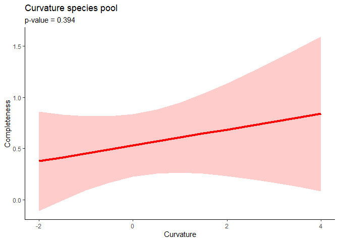

```r
# model residuals

#plot(simulateResiduals(completness_curve))

# predict completeness

comp_curve_pred=ggpredict(completness_curve,terms = c('Curvature[-2:4 by=0.5]'))

# extract p-value for plot

p <-summary(completness_curve)

p<-round(as.numeric(p[["coefficients"]][["cond"]][[11]]),3)

subtitle<- paste0("p-value = ",p)

#plot

plot_completeness_curv<-ggplot()+
  geom_line(data = comp_curve_pred,aes(x= x,y = predicted),size=1.5,color= "red")+
  geom_ribbon(data = comp_curve_pred,aes(x=x,ymin=conf.low,ymax=conf.high),alpha=0.2,fill="red")+
  xlab("Curvature") +
  ggtitle(label = "Curvature species pool",
          subtitle = subtitle)+
  ylab("Completeness")+theme_classic()


plot_completeness_curv
```

```r
rm(p,subtitle,comp_curve_pred)
```

#### Save curvature models table

models summery tables:

```r
# tab_model(curv_total, curv_observed, curv_dark, dv.labels = c("Species pool", "Observed richness", "Dark diversity"), file = "curvature_model_results.xls")
```

# Plot figure 3

combine all 6 plots of model predictions

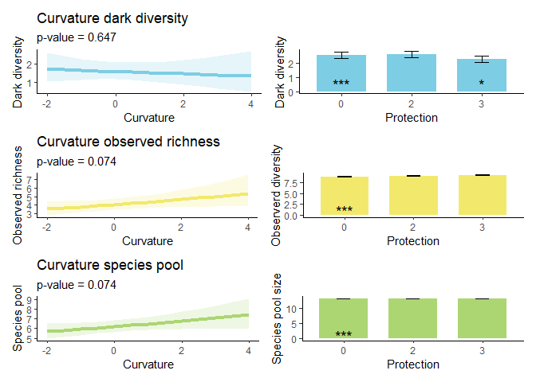

```r
a<- plot_dark_curv
b<- plot_dark_pro
c<-plot_observed_curv
d<-plot_obsrved_pro
e<-plot_total_curv
f<-plot_total_pro

predictions_plot <- (a+b)/(c+d)/(e+f)+
  plot_layout(heights = rep(10), widths = rep(5))

predictions_plot
```

```r
#ggsave("predictions_plot_new.pdf",predictions_plot, width = 10, height = 10)

rm(a,b,c,d,e,f)
```

## Vertical relief models

### vr dark diversity

```r
# model

vr_dark<-glmmTMB(log(dark+1) ~  VerRelief + protection+ (1|site), data=complexity_for_model,family = gaussian())

#summary

summary(vr_dark)
```

```
##  Family: gaussian  ( identity )
## Formula:          log(dark + 1) ~ VerRelief + protection + (1 | site)
## Data: complexity_for_model
##
##      AIC      BIC   logLik deviance df.resid
##    320.6    336.5   -155.3    310.6      174
##
## Random effects:
##
## Conditional model:
##  Groups   Name        Variance Std.Dev.
##  site     (Intercept) 0.01223  0.1106
##  Residual             0.32483  0.5699
## Number of obs: 179, groups:  site, 4
##
## Dispersion estimate for gaussian family (sigma^2): 0.325
##
## Conditional model:
##                       Estimate Std. Error z value Pr(>|z|)
## (Intercept)          0.9253104  0.0860385  10.755   <2e-16 ***
## VerRelief           -0.0680772  0.0494691  -1.376    0.169
## protectionProtected  0.0002941  0.0891717   0.003    0.997
## ---
## Signif. codes:  0 '***' 0.001 '**' 0.01 '*' 0.05 '.' 0.1 ' ' 1
```

```r
# plot mosel residuals

#plot(simulateResiduals(vr_dark))

# predicted dark diversity values

predicted_dark_vr=ggpredict(vr_dark,terms = c('VerRelief[-2:4 by=0.5]'))
```

```
## Model has log-transformed response. Back-transforming predictions to
##   original response scale. Standard errors are still on the log-scale.
```

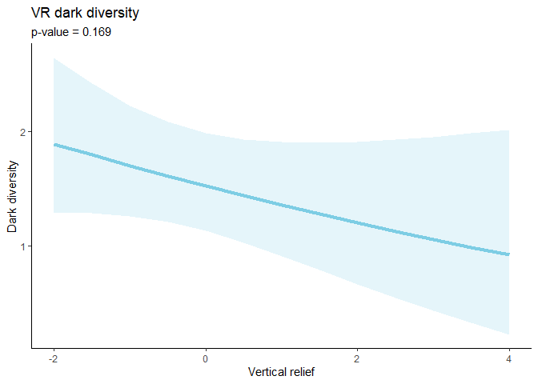

```r
# extract p-value for plot

p <-summary(vr_dark)

p<-round(as.numeric(p[["coefficients"]][["cond"]][[11]]),3)

subtitle<- paste0("p-value = ",p)

# plot


plot_dark_vr <- ggplot()+
  theme_classic()+
  geom_line(data = predicted_dark_vr,aes(x= x,y = predicted),size=1.5,color= "#7DCDE4")+
  geom_ribbon(data = predicted_dark_vr,aes(x=x,ymin=conf.low,ymax=conf.high),alpha=0.2,fill="#7DCDE4")+
  xlab("Vertical relief") +
  ylab("Dark diversity")+
  ggtitle(label = "VR dark diversity",
          subtitle = subtitle)

plot_dark_vr
```

```r
rm(p,subtitle,predicted_dark_vr)
```

### vr observed richness

```r
# run model
vr_observed<-glmmTMB(log(observed_richness) ~  VerRelief + protection+ (1|site), data=complexity_for_model,family = gaussian())

# summary

summary(vr_observed)
```

```
##  Family: gaussian  ( identity )
## Formula:          log(observed_richness) ~ VerRelief + protection + (1 | site)
## Data: complexity_for_model
##
##      AIC      BIC   logLik deviance df.resid
##    192.5    208.4    -91.2    182.5      174
##
## Random effects:
##
## Conditional model:
##  Groups   Name        Variance Std.Dev.
##  site     (Intercept) 0.01239  0.1113
##  Residual             0.15698  0.3962
## Number of obs: 179, groups:  site, 4
##
## Dispersion estimate for gaussian family (sigma^2): 0.157
##
## Conditional model:
##                     Estimate Std. Error z value Pr(>|z|)
## (Intercept)          1.43427    0.07181  19.973  < 2e-16 ***
## VerRelief            0.10325    0.03443   2.999  0.00271 **
## protectionProtected  0.03463    0.06228   0.556  0.57818
## ---
## Signif. codes:  0 '***' 0.001 '**' 0.01 '*' 0.05 '.' 0.1 ' ' 1
```

```r
# plot model residuals

#plot(simulateResiduals(vr_observed))

# predict vr values

predict_obs_vr=ggpredict(vr_observed,terms = c('VerRelief[-2:4 by=0.5]'))
```

```
## Model has log-transformed response. Back-transforming predictions to
##   original response scale. Standard errors are still on the log-scale.
```

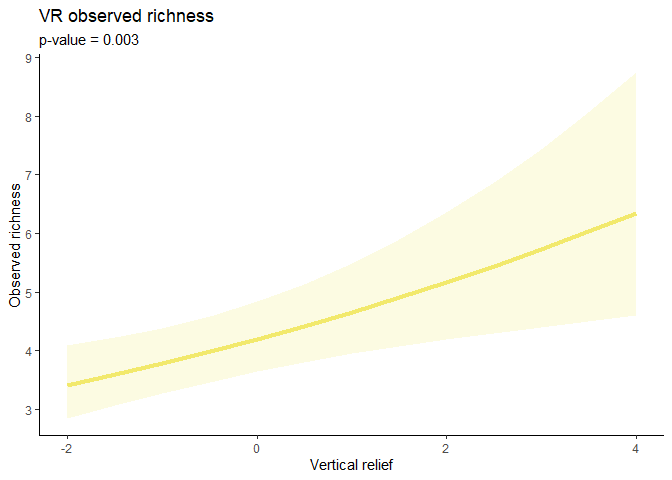

```r
# extract p-value for plot

p <-summary(vr_observed)

p<-round(as.numeric(p[["coefficients"]][["cond"]][[11]]),3)

subtitle<- paste0("p-value = ",p)

# plot

plot_observed_vr<-ggplot()+
  theme_classic()+
  geom_line(data = predict_obs_vr,aes(x= x,y = predicted),size=1.5,color= "#F2E96C")+
  geom_ribbon(data = predict_obs_vr,aes(x=x,ymin=conf.low,ymax=conf.high),alpha=0.2,fill="#F2E96C")+
  xlab("Vertical relief") +
  ylab("Observed richness")+
  ggtitle(label = "VR observed richness",
          subtitle = subtitle)

plot_observed_vr
```

```r
rm(p,subtitle,predict_obs_vr)
```

### vr species pool

```r
# run model
vr_total<-glmmTMB(log(total) ~  VerRelief + protection + (1|site), data=complexity_for_model,family = gaussian())

# summary

summary(vr_total)
```

```
##  Family: gaussian  ( identity )
## Formula:          log(total) ~ VerRelief + protection + (1 | site)
## Data: complexity_for_model
##
##      AIC      BIC   logLik deviance df.resid
##     25.8     41.8     -7.9     15.8      174
##
## Random effects:
##
## Conditional model:
##  Groups   Name        Variance Std.Dev.
##  site     (Intercept) 0.005488 0.07408
##  Residual             0.061750 0.24849
## Number of obs: 179, groups:  site, 4
##
## Dispersion estimate for gaussian family (sigma^2): 0.0617
##
## Conditional model:
##                     Estimate Std. Error z value Pr(>|z|)
## (Intercept)          1.84000    0.04666   39.44   <2e-16 ***
## VerRelief            0.03876    0.02106    1.84   0.0657 .
## protectionProtected  0.03578    0.03896    0.92   0.3584
## ---
## Signif. codes:  0 '***' 0.001 '**' 0.01 '*' 0.05 '.' 0.1 ' ' 1
```

```r
# plot model residuals

#plot(simulateResiduals(vr_total))

# predicted species pool values

predicted_total_vr=ggpredict(vr_total,terms = c('VerRelief[-2:4 by=0.5]'))
```

```
## Model has log-transformed response. Back-transforming predictions to
##   original response scale. Standard errors are still on the log-scale.
```

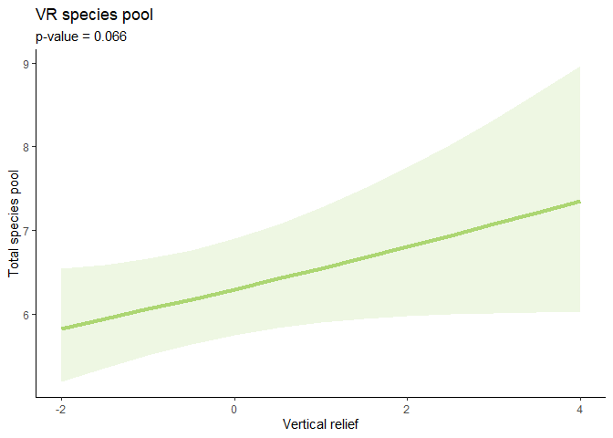

```r
# extract p-value for plot

p <-summary(vr_total)

p<-round(as.numeric(p[["coefficients"]][["cond"]][[11]]),3)

subtitle<- paste0("p-value = ",p)

# plot

plot_total_vr<-ggplot()+
  theme_classic()+
  geom_line(data = predicted_total_vr,aes(x= x,y = predicted),size=1.5,color= "#ACD672")+
  geom_ribbon(data = predicted_total_vr,aes(x=x,ymin=conf.low,ymax=conf.high),alpha=0.2,fill="#ACD672")+
  xlab("Vertical relief") +
  ylab("Total species pool")+
  ggtitle(label = "VR species pool",
          subtitle = subtitle)

plot_total_vr
```

```r
rm(predicted_total_vr,p,subtitle)
```

check for interaction between protection and habitat quality - dark diversity

```r
int_vr_dark<-glmmTMB(log(dark+1) ~  VerRelief * protection+ (1|site), data=complexity_for_model,family = gaussian())

summary(int_vr_dark)
```

```
##  Family: gaussian  ( identity )
## Formula:          log(dark + 1) ~ VerRelief * protection + (1 | site)
## Data: complexity_for_model
##
##      AIC      BIC   logLik deviance df.resid
##    316.5    335.6   -152.3    304.5      173
##
## Random effects:
##
## Conditional model:
##  Groups   Name        Variance Std.Dev.
##  site     (Intercept) 0.01071  0.1035
##  Residual             0.31443  0.5607
## Number of obs: 179, groups:  site, 4
##
## Dispersion estimate for gaussian family (sigma^2): 0.314
##
## Conditional model:
##                               Estimate Std. Error z value Pr(>|z|)
## (Intercept)                    0.96058    0.08413  11.417   <2e-16 ***
## VerRelief                      0.09571    0.08191   1.168    0.243
## protectionProtected           -0.02346    0.08831  -0.266    0.790
## VerRelief:protectionProtected -0.23483    0.09456  -2.483    0.013 *
## ---
## Signif. codes:  0 '***' 0.001 '**' 0.01 '*' 0.05 '.' 0.1 ' ' 1
```

```r
ms_vr_dark<-as.data.frame(model.sel(int_vr_dark,vr_dark))

ms_vr_dark <- tibble::rownames_to_column(ms_vr_dark, "Model")

ms_vr_dark$type<-rep("Dark diversity")
```

check for interaction between protection and habitat quality - observed rishness

```r
int_vr_observed<-glmmTMB(log(observed_richness) ~  VerRelief * protection+ (1|site), data=complexity_for_model,family = gaussian())

summary(int_vr_observed)
```

```
##  Family: gaussian  ( identity )
## Formula:          log(observed_richness) ~ VerRelief * protection + (1 | site)
## Data: complexity_for_model
##
##      AIC      BIC   logLik deviance df.resid
##    194.3    213.4    -91.1    182.3      173
##
## Random effects:
##
## Conditional model:
##  Groups   Name        Variance Std.Dev.
##  site     (Intercept) 0.01227  0.1108
##  Residual             0.15681  0.3960
## Number of obs: 179, groups:  site, 4
##
## Dispersion estimate for gaussian family (sigma^2): 0.157
##
## Conditional model:
##                               Estimate Std. Error z value Pr(>|z|)
## (Intercept)                    1.42961    0.07230  19.773   <2e-16 ***
## VerRelief                      0.08166    0.05814   1.405    0.160
## protectionProtected            0.03787    0.06265   0.604    0.546
## VerRelief:protectionProtected  0.03077    0.06684   0.460    0.645
## ---
## Signif. codes:  0 '***' 0.001 '**' 0.01 '*' 0.05 '.' 0.1 ' ' 1
```

```r
ms_vr_obs<-as.data.frame(model.sel(int_vr_observed,vr_observed))

ms_vr_obs <- tibble::rownames_to_column(ms_vr_obs, "Model")

ms_vr_obs$type<-rep("Observed richness")
```

check for interaction between protection and habitat quality - species pool

```r
int_vr_total<-glmmTMB(log(total) ~  VerRelief * protection + (1|site), data=complexity_for_model,family = gaussian())

summary(int_vr_total)
```

```
##  Family: gaussian  ( identity )
## Formula:          log(total) ~ VerRelief * protection + (1 | site)
## Data: complexity_for_model
##
##      AIC      BIC   logLik deviance df.resid
##     24.8     43.9     -6.4     12.8      173
##
## Random effects:
##
## Conditional model:
##  Groups   Name        Variance Std.Dev.
##  site     (Intercept) 0.005417 0.0736
##  Residual             0.060715 0.2464
## Number of obs: 179, groups:  site, 4
##
## Dispersion estimate for gaussian family (sigma^2): 0.0607
##
## Conditional model:
##                               Estimate Std. Error z value Pr(>|z|)
## (Intercept)                    1.85106    0.04675   39.59   <2e-16 ***
## VerRelief                      0.08979    0.03596    2.50   0.0125 *
## protectionProtected            0.02802    0.03888    0.72   0.4711
## VerRelief:protectionProtected -0.07251    0.04159   -1.74   0.0813 .
## ---
## Signif. codes:  0 '***' 0.001 '**' 0.01 '*' 0.05 '.' 0.1 ' ' 1
```

```r
ms_vr_total<-as.data.frame(model.sel(int_vr_total,vr_total))

ms_vr_total <- tibble::rownames_to_column(ms_vr_total, "Model")

ms_vr_total$type<-rep("Total species pool")
```

unite tables and save

```r
ms_vr<-bind_rows(ms_vr_obs,ms_vr_dark,ms_vr_total)


ms_vr<-ms_vr %>% relocate(type,.before = Model)

ms_vr<-ms_vr %>% select(-(3:7))

#write.csv(ms_vr,"ms_vr.csv")
```

### vr completness

```r
# model
completeness_vr<-glmmTMB(completeness ~  VerRelief + protection+ (1|site), data=complexity_comp,family = gaussian())

# summary

summary(completeness_vr)
```

```
##  Family: gaussian  ( identity )
## Formula:          completeness ~ VerRelief + protection + (1 | site)
## Data: complexity_comp
##
##      AIC      BIC   logLik deviance df.resid
##    337.6    352.2   -163.8    327.6      133
##
## Random effects:
##
## Conditional model:
##  Groups   Name        Variance Std.Dev.
##  site     (Intercept) 0.02204  0.1484
##  Residual             0.61423  0.7837
## Number of obs: 138, groups:  site, 4
##
## Dispersion estimate for gaussian family (sigma^2): 0.614
##
## Conditional model:
##                     Estimate Std. Error z value Pr(>|z|)
## (Intercept)          0.59873    0.12532   4.778 1.77e-06 ***
## VerRelief            0.24473    0.08312   2.944  0.00324 **
## protectionProtected  0.02933    0.13879   0.211  0.83263
## ---
## Signif. codes:  0 '***' 0.001 '**' 0.01 '*' 0.05 '.' 0.1 ' ' 1
```

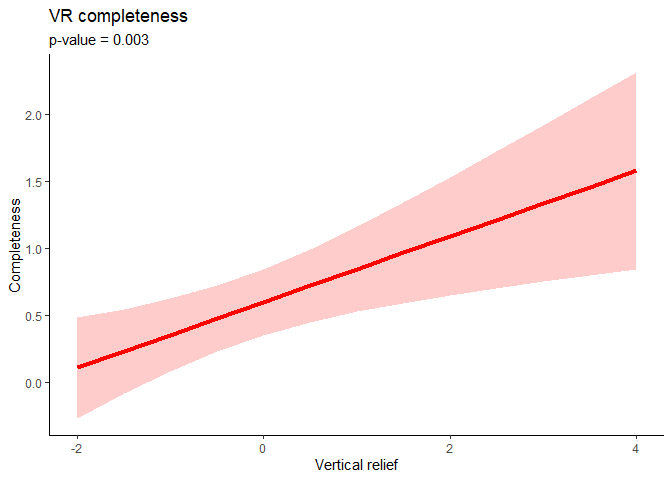

```r
# plot model residuals

#plot(simulateResiduals(completeness_vr))

# predicted completeness values

predicted_comp_vr=ggpredict(completeness_vr,terms = c('VerRelief[-2:4 by=0.5]'))

# extract p-value for plot

p <-summary(completeness_vr)

p<-round(as.numeric(p[["coefficients"]][["cond"]][[11]]),3)

subtitle<- paste0("p-value = ",p)

# plot

plot_completeness_vr<-ggplot()+
  theme_classic()+
  geom_line(data = predicted_comp_vr,aes(x= x,y = predicted),size=1.5,color= "red")+
  geom_ribbon(data = predicted_comp_vr,aes(x=x,ymin=conf.low,ymax=conf.high),alpha=0.2,fill="red")+
  xlab("Vertical relief") +
  ylab("Completeness")+
  ggtitle(label = "VR completeness",
          subtitle = subtitle)

plot_completeness_vr
```

```r
rm(predicted_comp_vr,p,subtitle)
```

### Save vr models table

models summery tables:

```r
# tab_model(vr_total, vr_observed, vr_dark, dv.labels = c("Species pool", "Observed richness", "Dark diversity"), file = "vr_model_results.xls")
```

# Plot vertical relief appendix

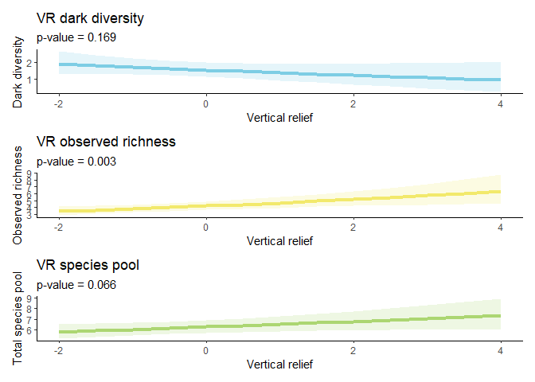

```r
a<- plot_dark_vr
b<- plot_observed_vr
c<- plot_total_vr


vr_predictions_plot <- a/b/c +
  plot_layout(heights = rep(10), widths = rep(5))

vr_predictions_plot
```

```r
#ggsave("vr_predictions_plot.pdf",vr_predictions_plot, width = 5, height = 10)

rm(a,b,c)
```

# Plot completness appendix

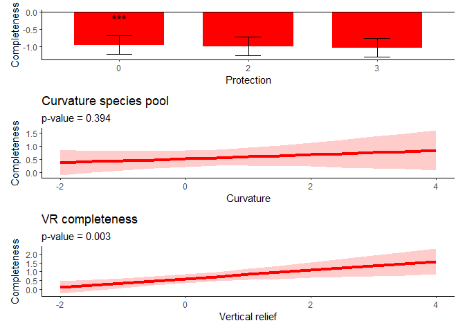

```r
a<- plot_completness_pro
b<- plot_completeness_curv
c<- plot_completeness_vr


completeness_prediction_plot <- a/b/c +
  plot_layout(heights = rep(10), widths = rep(5))

completeness_prediction_plot
```

```r
#ggsave("completeness_prediction_plot.pdf",completeness_prediction_plot,width = 5, height = 10)

rm(a,b,c)
```

### Save completness models table

models summery tables:

```r
# tab_model(completeness_model, completness_curve, completeness_vr, dv.labels = c("Protection", "Curvature", "Vertical relief"), file = "completenes_model_results_new.xls")
```